# C3하지혜_0526과제

## 의사결정나무

```python
import pandas as pd

import matplotlib.pyplot as plt
import matplotlib

from sklearn.tree import export_graphviz

import graphviz

from sklearn.model_selection import train_test_split
from sklearn.tree import DecisionTreeClassifier

from sklearn.model_selection import GridSearchCV

from sklearn.metrics import accuracy_score, f1_score
from sklearn.metrics import confusion_matrix, classification_report
```

```python
matplotlib.rc('font', family='NanumGothic')
matplotlib.rcParams['axes.unicode_minus'] = False
plt.rcParams["font.family"] = 'NanumGothic'
```

### 데이터 구성하기

```python
df_raw = pd.read_csv('../빅데이터 기초/Data/유방암.csv',encoding='euc-kr')
df_raw.head()
```

|  | diagnosis | mean_radius | mean_texture | mean_perimeter | mean_area | mean_smoothness | mean_compactness | mean_concavity | mean_concave_points | mean_symmetry | ... | worst_radius | worst_texture | worst_perimeter | worst_area | worst_smoothness | worst_compactness | worst_concavity | worst_concave_points | worst_symmetry | worst_fractal_dimension |
| --- | --- | --- | --- | --- | --- | --- | --- | --- | --- | --- | --- | --- | --- | --- | --- | --- | --- | --- | --- | --- | --- |
| 0 | 음성 | 15.12 | 16.68 | 98.78 | 716.6 | 0.08876 | 0.09588 | 0.07550 | 0.04079 | 0.1594 | ... | 17.77 | 20.24 | 117.70 | 989.5 | 0.14910 | 0.3331 | 0.3327 | 0.12520 | 0.3415 | 0.09740 |
| 1 | 양성 | 10.80 | 9.71 | 68.77 | 357.6 | 0.09594 | 0.05736 | 0.02531 | 0.01698 | 0.1381 | ... | 11.60 | 12.02 | 73.66 | 414.0 | 0.14360 | 0.1257 | 0.1047 | 0.04603 | 0.2090 | 0.07699 |
| 2 | 음성 | 18.31 | 18.58 | 118.60 | 1041.0 | 0.08588 | 0.08468 | 0.08169 | 0.05814 | 0.1621 | ... | 21.31 | 26.36 | 139.20 | 1410.0 | 0.12340 | 0.2445 | 0.3538 | 0.15710 | 0.3206 | 0.06938 |
| 3 | 양성 | 14.92 | 14.93 | 96.45 | 686.9 | 0.08098 | 0.08549 | 0.05539 | 0.03221 | 0.1687 | ... | 17.18 | 18.22 | 112.00 | 906.6 | 0.10650 | 0.2791 | 0.3151 | 0.11470 | 0.2688 | 0.08273 |
| 4 | 양성 | 12.89 | 13.12 | 81.89 | 515.9 | 0.06955 | 0.03729 | 0.02260 | 0.01171 | 0.1337 | ... | 13.62 | 15.54 | 87.40 | 577.0 | 0.09616 | 0.1147 | 0.1186 | 0.05366 | 0.2309 | 0.06915 |

5 rows × 31 columns

```python
# 데이터 분리 (Y, Xs) -> 설명변수를 이용한 주성분 분석
df_raw_x = df_raw.drop("diagnosis", axis = 1)
df_raw_y = df_raw["diagnosis"]
df_raw_y.head()
```

```
0    음성
1    양성
2    음성
3    양성
4    양성
Name: diagnosis, dtype: object
```

```python
df_raw_y.replace("양성", 1, inplace=True)
df_raw_y.replace("음성", 0, inplace=True)
```

양성을 1, 음성을 0으로 변환하였다.

```python
df_raw_y.head()
```

```
0    0
1    1
2    0
3    1
4    1
Name: diagnosis, dtype: int64
```

```python
df_raw['diagnosis'].value_counts() # oversampling 안해도 될 것 같다.
```

```
0    212
1    108
Name: diagnosis, dtype: int64
```

```python
# get dummies : 데이터의 문자형 변수에 대한 더미변수 생성
df_raw_dummy = pd.get_dummies(df_raw)
# 더미변수 생성된 데이터의 상위 5개 row 확인
df_raw_dummy.head()
```

|  | diagnosis | mean_radius | mean_texture | mean_perimeter | mean_area | mean_smoothness | mean_compactness | mean_concavity | mean_concave_points | mean_symmetry | ... | worst_radius | worst_texture | worst_perimeter | worst_area | worst_smoothness | worst_compactness | worst_concavity | worst_concave_points | worst_symmetry | worst_fractal_dimension |
| --- | --- | --- | --- | --- | --- | --- | --- | --- | --- | --- | --- | --- | --- | --- | --- | --- | --- | --- | --- | --- | --- |
| 0 | 0 | 15.12 | 16.68 | 98.78 | 716.6 | 0.08876 | 0.09588 | 0.07550 | 0.04079 | 0.1594 | ... | 17.77 | 20.24 | 117.70 | 989.5 | 0.14910 | 0.3331 | 0.3327 | 0.12520 | 0.3415 | 0.09740 |
| 1 | 1 | 10.80 | 9.71 | 68.77 | 357.6 | 0.09594 | 0.05736 | 0.02531 | 0.01698 | 0.1381 | ... | 11.60 | 12.02 | 73.66 | 414.0 | 0.14360 | 0.1257 | 0.1047 | 0.04603 | 0.2090 | 0.07699 |
| 2 | 0 | 18.31 | 18.58 | 118.60 | 1041.0 | 0.08588 | 0.08468 | 0.08169 | 0.05814 | 0.1621 | ... | 21.31 | 26.36 | 139.20 | 1410.0 | 0.12340 | 0.2445 | 0.3538 | 0.15710 | 0.3206 | 0.06938 |
| 3 | 1 | 14.92 | 14.93 | 96.45 | 686.9 | 0.08098 | 0.08549 | 0.05539 | 0.03221 | 0.1687 | ... | 17.18 | 18.22 | 112.00 | 906.6 | 0.10650 | 0.2791 | 0.3151 | 0.11470 | 0.2688 | 0.08273 |
| 4 | 1 | 12.89 | 13.12 | 81.89 | 515.9 | 0.06955 | 0.03729 | 0.02260 | 0.01171 | 0.1337 | ... | 13.62 | 15.54 | 87.40 | 577.0 | 0.09616 | 0.1147 | 0.1186 | 0.05366 | 0.2309 | 0.06915 |

5 rows × 31 columns

```python
# 설명변수, 목표변수 데이터 구분
df_raw_x = df_raw_dummy.drop("diagnosis", axis = 1, inplace= False)
df_raw_y = df_raw_dummy["diagnosis"]

# 데이터 분할 train_test_split(X:설명변수, Y: 목표변수 , test_size = test 데이터 비율)
df_train_x, df_test_x, df_train_y, df_test_y = train_test_split(df_raw_x, df_raw_y, test_size= 0.4, random_state=1234)
print("분할 전 설명변수 데이터: ", df_raw_x.shape)
print("분할 후 설명변수 데이터: Train", df_raw_x.shape, "Test", df_test_x.shape)
```

```
분할 전 설명변수 데이터:  (320, 30)
분할 후 설명변수 데이터: Train (320, 30) Test (128, 30)
```

### 모델 생성

```python
#기본 옵션으로 모델 생성
tree_uncustomized = DecisionTreeClassifier(random_state=1234)
tree_uncustomized.fit(df_train_x,df_train_y)

#train 데이터 정확도
print("Accuracy on training set: {:.3f}".format(tree_uncustomized.score(df_train_x,df_train_y)))

#test 데이터 정확도
print("Accuracy on test set: {:.3f}".format(tree_uncustomized.score(df_test_x,df_test_y)))
```

```
Accuracy on training set: 1.000
Accuracy on test set: 0.883
```

```python
#현재 생성된 모델의 옵션 확인
tree_uncustomized
```

```
DecisionTreeClassifier(random_state=1234)
```

```python
# max_depth : 최대 깊이 변경에 따른 모델 성능
#train 및 test 정확도 결과 저장용
train_accuracy = []; test_accuracy = []

#max_depth: 최대 깊이 변경
para_depth = [depth for depth in range(1,11)]
for v_max_depth in para_depth:
    tree = DecisionTreeClassifier(max_depth=v_max_depth, random_state=1234)
    tree.fit(df_train_x,df_train_y)
    train_accuracy.append(tree.score(df_train_x,df_train_y))
    test_accuracy.append(tree.score(df_test_x,df_test_y))

#데이터 테이블로 저장
df_accuracy_depth = pd.DataFrame()
df_accuracy_depth['Depth'] = para_depth
df_accuracy_depth['TrainAccuracy'] = train_accuracy
df_accuracy_depth['TestAccuracy'] = test_accuracy
```

### 모델 Parameter 조정

#### 깊이 조정

```python
# 모델 정확도 확인
df_accuracy_depth.round(3)
```

|  | Depth | TrainAccuracy | TestAccuracy |
| --- | --- | --- | --- |
| 0 | 1 | 0.932 | 0.852 |
| 1 | 2 | 0.979 | 0.875 |
| 2 | 3 | 0.995 | 0.875 |
| 3 | 4 | 1.000 | 0.883 |
| 4 | 5 | 1.000 | 0.883 |
| 5 | 6 | 1.000 | 0.883 |
| 6 | 7 | 1.000 | 0.883 |
| 7 | 8 | 1.000 | 0.883 |
| 8 | 9 | 1.000 | 0.883 |
| 9 | 10 | 1.000 | 0.883 |

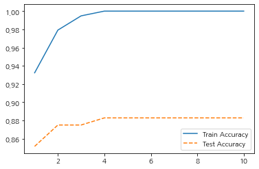

```python
#모델 정확도 그래프 확인
plt.plot(para_depth, train_accuracy, linestyle ="-", label = "Train Accuracy")
plt.plot(para_depth, test_accuracy, linestyle ="--", label = "Test Accuracy")
plt.legend()
```

- 최대 깊이 증가에 따라 모델의 정확도가 증가한다.
- Train/Test 데이터의 성능 변화를 고려하여 깊이는 4를 선택하였다.

다음은 깊이가 4인 모델이다.

```python
#변수명저장
v_feature_name = df_train_x.columns

#깊이가 4인 모델
tree_low = DecisionTreeClassifier(max_depth = 4, random_state=1234)
tree_low.fit(df_train_x, df_train_y)

#트리 모델을 tree_low.dot 파일로 저장. (목표변수, 0: Good, 1: Bad)
export_graphviz(tree_low, out_file="tree_low.dot", class_names = ["Good","Bad"],
               feature_names = v_feature_name, impurity= True, filled= True)
#graphviz 를 이용해 트리모델 시각화
with open("tree_low.dot")as f:
    dot_graph = f.read()
display(graphviz.Source(dot_graph))
```

[figure not shown]

- worst_concave_points, area_error, worst_concavity 등의 변수가 영향력이 높은 것을 확인할 수 있다.

#### min_sample_split 조정

```python
# train 및 test 정확도 결과 저장용
train_accuracy = []
test_accuracy = []

# min_sample_split: 분할하기 위한 노드의 최소 샘플 수
para_split = [n_split * 10 for n_split in range(1, 11)]

for v_min_samples_split in para_split:
    tree = DecisionTreeClassifier(min_samples_split=v_min_samples_split, max_depth=4, random_state=1234)
    tree.fit(df_train_x, df_train_y)
    train_accuracy.append(tree.score(df_train_x, df_train_y))
    test_accuracy.append(tree.score(df_test_x, df_test_y))

# 데이터 테이블로 저장
df_accuracy_split = pd.DataFrame()
df_accuracy_split["MinSamplesSplit"] = para_split
df_accuracy_split["TrainAccuracy"] = train_accuracy
df_accuracy_split["TestAccuracy"] = test_accuracy
```

```python
# 모델 정확도 확인
df_accuracy_split.round(3)
```

|  | MinSamplesSplit | TrainAccuracy | TestAccuracy |
| --- | --- | --- | --- |
| 0 | 10 | 0.995 | 0.875 |
| 1 | 20 | 0.995 | 0.875 |
| 2 | 30 | 0.995 | 0.875 |
| 3 | 40 | 0.995 | 0.875 |
| 4 | 50 | 0.995 | 0.875 |
| 5 | 60 | 0.995 | 0.875 |
| 6 | 70 | 0.995 | 0.875 |
| 7 | 80 | 0.984 | 0.867 |
| 8 | 90 | 0.953 | 0.844 |
| 9 | 100 | 0.953 | 0.844 |

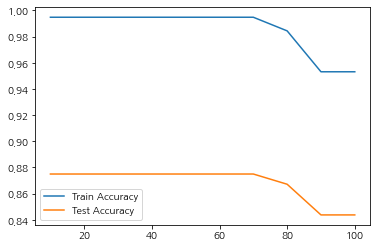

```python
# 모델 정확도 그래프 확인
plt.plot(para_split, train_accuracy, linestyle="-", label="Train Accuracy")
plt.plot(para_split, test_accuracy, linestyle="-", label="Test Accuracy")
plt.legend()
```

- 분리 노드의 최소 자료 수 증가에 따라 모델의 정확도는 감소한다.
- Train/Test 데이터의 성능 변화를 고려하면 10~70까지 동일하지만, 추후 모델이 너무 세세해지는 것을 막기 위해 적당히 50을 선택할 것이다.

다음은 분리노드 수가 50인 모델을 나타낸 것이다.

```python
#모델 parameter 조정, 분리노드 50인 모델
tree_low= DecisionTreeClassifier(max_depth=4,min_samples_split=50,random_state=1234)
tree_low.fit(df_train_x,df_train_y)

export_graphviz(tree_low,out_file="tree_low.dot",class_names=["Good","Bad"],
               feature_names=v_feature_name,impurity=True,filled=True)

with open("tree_low.dot")as f:
    dot_graph=f.read()
display(graphviz.Source(dot_graph))
```

[figure not shown]

- worst_concave_points, area_error, worst_concavity 등의 변수가 영향력이 높은 것을 확인할 수 있다.

#### min_samples_leaf 조정

```python
train_accuracy=[]
test_accuracy=[]

para_leaf=[n_leaf * 2 for n_leaf in range(1,11)]

for v_min_samples_leaf in para_leaf:
    tree = DecisionTreeClassifier(min_samples_leaf=v_min_samples_leaf,min_samples_split=20, max_depth=4, random_state=1234)
    tree.fit(df_train_x, df_train_y)
    train_accuracy.append(tree.score(df_train_x, df_train_y))
    test_accuracy.append(tree.score(df_test_x, df_test_y))

    # 데이터 테이블로 저장
df_accuracy_leaf = pd.DataFrame()
df_accuracy_leaf["MinSamplesLeaf"] = para_leaf
df_accuracy_leaf["TrainAccuracy"] = train_accuracy
df_accuracy_leaf["TestAccuracy"] = test_accuracy
```

```python
# 모델 정확도 확인
df_accuracy_leaf.round(3)
```

|  | MinSamplesLeaf | TrainAccuracy | TestAccuracy |
| --- | --- | --- | --- |
| 0 | 2 | 0.995 | 0.875 |
| 1 | 4 | 0.974 | 0.891 |
| 2 | 6 | 0.964 | 0.875 |
| 3 | 8 | 0.958 | 0.898 |
| 4 | 10 | 0.953 | 0.914 |
| 5 | 12 | 0.943 | 0.906 |
| 6 | 14 | 0.932 | 0.898 |
| 7 | 16 | 0.932 | 0.852 |
| 8 | 18 | 0.932 | 0.852 |
| 9 | 20 | 0.932 | 0.852 |

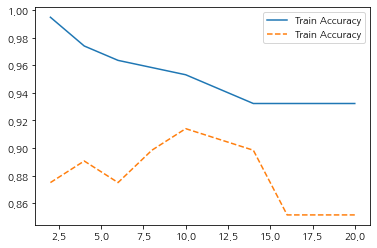

```python
# 모델 정확도 그래프 확인
plt.plot(para_leaf,train_accuracy, linestyle = "-",label="Train Accuracy")
plt.plot(para_leaf,test_accuracy,linestyle ="--",label="Train Accuracy")
plt.legend()
```

- 잎사귀 노드의 최소 자료 수 증가에 따라 모델의 정확도는 감소한다.
- Train/Test 데이터의 성능 변화를 고려하여 10을 선택할 것이다.

다음은 잎사귀 노드의 최소 자료 수가 10인 모델을 나타낸 것이다.

```python
#min_samples_leaf : 잎사귀 노드의 최소 자료 수 변경에 따른 모델 성능
#잎사귀 최소 자료수가 10인 모델
tree_low = DecisionTreeClassifier(max_depth=4, min_samples_split=50, min_samples_leaf=10, random_state=1234)
tree_low.fit(df_train_x,df_train_y)
export_graphviz(tree_low,out_file='tree_low.dot',class_names=['Good','Bad'],
               feature_names=v_feature_name,impurity=True,filled=True)
with open('tree_low.dot') as f:
    dot_graph = f.read()
display(graphviz.Source(dot_graph))
```

[figure not shown]

### 최종 모델 선정

```python
# 최종 모델 선정
tree_final = DecisionTreeClassifier(min_samples_leaf=10, min_samples_split=50, max_depth= 4, random_state=1234)
tree_final.fit(df_train_x, df_train_y)
```

```
DecisionTreeClassifier(max_depth=4, min_samples_leaf=10, min_samples_split=50,
                       random_state=1234)
```

```python
# tree_final.dot으로 결과 저장
export_graphviz(tree_final, out_file = "tree_final.dot", class_names = ["Good", "Bad"], feature_names = v_feature_name, impurity = True, filled = True)
with open ("tree_final.dot") as f:
    dot_graph = f.read()
display(graphviz.Source(dot_graph))
```

[figure not shown]

- 트리 분리에 영향이 큰 변수는 worst_concave_points, worst_area, worst_radius 등이다.
- 즉, 오목함의 정도와 영역의 크기, 반지름 등이 유방암의 발병와 영향이 크다고 할 수 있다.

### 최종 모델을 이용한 분류 예측

```python
# 평가
y_pred=tree_final.predict(df_test_x)

print("Accuracy:{0:.3f}\n".format(tree_final.score(df_test_x,df_test_y)))
print("Confusion matrix: \n".format(confusion_matrix(df_test_y,y_pred)))
print(classification_report(df_test_y,y_pred, digits=3))
```

```
Accuracy:0.914

Confusion matrix:

              precision    recall  f1-score   support

           0      0.922     0.969     0.945        97
           1      0.885     0.742     0.807        31

    accuracy                          0.914       128
   macro avg      0.903     0.856     0.876       128
weighted avg      0.913     0.914     0.911       128
```

- 1 기준 f1-score는 80.7%이다.
- 1 기준 precision은 88.5%이다.
- 0 기준으로 보았을 때보다 예측 확률은 낮지만 80%가 넘는다는 점에서 충분히 사용 가능한 모델인 것 같다.

### 결론

```python
# tree.feature_importances_로 설명변수 중요도 확인 및 테이블로 저장
df_importance = pd.DataFrame()
df_importance["Feature"] = v_feature_name
df_importance["Importance"] = tree_final.feature_importances_

# df_feature_importance의 테이블을 중요도 순으로 정렬
df_importance.sort_values("Importance", ascending=False, inplace=True)
df_importance.round(3)
```

|  | Feature | Importance |
| --- | --- | --- |
| 27 | worst_concave_points | 0.848 |
| 23 | worst_area | 0.116 |
| 20 | worst_radius | 0.031 |
| 12 | perimeter_error | 0.003 |
| 17 | concave_points_error | 0.003 |
| 0 | mean_radius | 0.000 |
| 16 | concavity_error | 0.000 |
| 28 | worst_symmetry | 0.000 |
| 26 | worst_concavity | 0.000 |
| 25 | worst_compactness | 0.000 |
| 24 | worst_smoothness | 0.000 |
| 22 | worst_perimeter | 0.000 |
| 21 | worst_texture | 0.000 |
| 19 | fractal_dimension_error | 0.000 |
| 18 | symmetry_error | 0.000 |
| 15 | compactness_error | 0.000 |
| 1 | mean_texture | 0.000 |
| 14 | smoothness_error | 0.000 |
| 13 | area_error | 0.000 |
| 11 | texture_error | 0.000 |
| 10 | radius_error | 0.000 |
| 9 | mean_fractal_dimension | 0.000 |
| 8 | mean_symmetry | 0.000 |
| 7 | mean_concave_points | 0.000 |
| 6 | mean_concavity | 0.000 |
| 5 | mean_compactness | 0.000 |
| 4 | mean_smoothness | 0.000 |
| 3 | mean_area | 0.000 |
| 2 | mean_perimeter | 0.000 |
| 29 | worst_fractal_dimension | 0.000 |

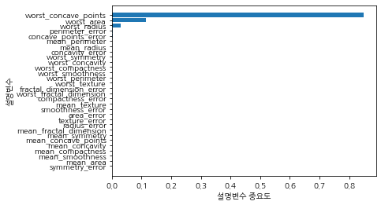

```python
# 설명변수 중요도 그래프
# 중요도가 높은 변수를 상위에 그림
df_importance.sort_values("Importance", ascending=True, inplace=True)
coordinates = range(len(df_importance))
plt.barh(y=coordinates, width=df_importance["Importance"])
plt.yticks(coordinates, df_importance["Feature"])
plt.xlabel("설명변수 중요도")
plt.ylabel("설명변수")
```

- 중요 설명변수는 worst_concave_points, worst_area, worst_radius이다.
- 특히, worst_concave_points는 다른 변수들에 비해 압도적으로 높은 중요도를 보였다.
- 하지만 0에 가까운 변수들이 중요하지 않은 것이 아니며, train 데이터에 따라서 변수들의 중요도는 변경될 수 있다.

## 랜덤포레스트

```python
import pandas as pd

import matplotlib.pyplot as plt
import matplotlib

from sklearn.tree import export_graphviz

#import graphviz

from sklearn.model_selection import train_test_split
from sklearn.ensemble import RandomForestClassifier

from sklearn.model_selection import GridSearchCV

from sklearn.metrics import accuracy_score, f1_score
from sklearn.metrics import confusion_matrix, classification_report
```

### 데이터 구성하기

```python
df_raw = pd.read_csv('../빅데이터 기초/Data/유방암.csv',encoding='euc-kr')
df_raw.head()
```

|  | diagnosis | mean_radius | mean_texture | mean_perimeter | mean_area | mean_smoothness | mean_compactness | mean_concavity | mean_concave_points | mean_symmetry | ... | worst_radius | worst_texture | worst_perimeter | worst_area | worst_smoothness | worst_compactness | worst_concavity | worst_concave_points | worst_symmetry | worst_fractal_dimension |
| --- | --- | --- | --- | --- | --- | --- | --- | --- | --- | --- | --- | --- | --- | --- | --- | --- | --- | --- | --- | --- | --- |
| 0 | 음성 | 15.12 | 16.68 | 98.78 | 716.6 | 0.08876 | 0.09588 | 0.07550 | 0.04079 | 0.1594 | ... | 17.77 | 20.24 | 117.70 | 989.5 | 0.14910 | 0.3331 | 0.3327 | 0.12520 | 0.3415 | 0.09740 |
| 1 | 양성 | 10.80 | 9.71 | 68.77 | 357.6 | 0.09594 | 0.05736 | 0.02531 | 0.01698 | 0.1381 | ... | 11.60 | 12.02 | 73.66 | 414.0 | 0.14360 | 0.1257 | 0.1047 | 0.04603 | 0.2090 | 0.07699 |
| 2 | 음성 | 18.31 | 18.58 | 118.60 | 1041.0 | 0.08588 | 0.08468 | 0.08169 | 0.05814 | 0.1621 | ... | 21.31 | 26.36 | 139.20 | 1410.0 | 0.12340 | 0.2445 | 0.3538 | 0.15710 | 0.3206 | 0.06938 |
| 3 | 양성 | 14.92 | 14.93 | 96.45 | 686.9 | 0.08098 | 0.08549 | 0.05539 | 0.03221 | 0.1687 | ... | 17.18 | 18.22 | 112.00 | 906.6 | 0.10650 | 0.2791 | 0.3151 | 0.11470 | 0.2688 | 0.08273 |
| 4 | 양성 | 12.89 | 13.12 | 81.89 | 515.9 | 0.06955 | 0.03729 | 0.02260 | 0.01171 | 0.1337 | ... | 13.62 | 15.54 | 87.40 | 577.0 | 0.09616 | 0.1147 | 0.1186 | 0.05366 | 0.2309 | 0.06915 |

5 rows × 31 columns

```python
# 데이터 분리 (Y, Xs) -> 설명변수를 이용한 주성분 분석
df_raw_x = df_raw.drop("diagnosis", axis = 1)
df_raw_y = df_raw["diagnosis"]
df_raw_y.head()
```

```
0    음성
1    양성
2    음성
3    양성
4    양성
Name: diagnosis, dtype: object
```

```python
df_raw_y.replace("양성", 1, inplace=True)
df_raw_y.replace("음성", 0, inplace=True)
```

양성을 1, 음성을 0으로 변환하였다.

```python
df_raw_y.head()
```

```
0    0
1    1
2    0
3    1
4    1
Name: diagnosis, dtype: int64
```

```python
df_raw['diagnosis'].value_counts() # oversampling 안해도 될 것 같다.
```

```
0    212
1    108
Name: diagnosis, dtype: int64
```

```python
# get dummies : 데이터의 문자형 변수에 대한 더미변수 생성
df_raw_dummy = pd.get_dummies(df_raw)
# 더미변수 생성된 데이터의 상위 5개 row 확인
df_raw_dummy.head()
```

|  | diagnosis | mean_radius | mean_texture | mean_perimeter | mean_area | mean_smoothness | mean_compactness | mean_concavity | mean_concave_points | mean_symmetry | ... | worst_radius | worst_texture | worst_perimeter | worst_area | worst_smoothness | worst_compactness | worst_concavity | worst_concave_points | worst_symmetry | worst_fractal_dimension |
| --- | --- | --- | --- | --- | --- | --- | --- | --- | --- | --- | --- | --- | --- | --- | --- | --- | --- | --- | --- | --- | --- |
| 0 | 0 | 15.12 | 16.68 | 98.78 | 716.6 | 0.08876 | 0.09588 | 0.07550 | 0.04079 | 0.1594 | ... | 17.77 | 20.24 | 117.70 | 989.5 | 0.14910 | 0.3331 | 0.3327 | 0.12520 | 0.3415 | 0.09740 |
| 1 | 1 | 10.80 | 9.71 | 68.77 | 357.6 | 0.09594 | 0.05736 | 0.02531 | 0.01698 | 0.1381 | ... | 11.60 | 12.02 | 73.66 | 414.0 | 0.14360 | 0.1257 | 0.1047 | 0.04603 | 0.2090 | 0.07699 |
| 2 | 0 | 18.31 | 18.58 | 118.60 | 1041.0 | 0.08588 | 0.08468 | 0.08169 | 0.05814 | 0.1621 | ... | 21.31 | 26.36 | 139.20 | 1410.0 | 0.12340 | 0.2445 | 0.3538 | 0.15710 | 0.3206 | 0.06938 |
| 3 | 1 | 14.92 | 14.93 | 96.45 | 686.9 | 0.08098 | 0.08549 | 0.05539 | 0.03221 | 0.1687 | ... | 17.18 | 18.22 | 112.00 | 906.6 | 0.10650 | 0.2791 | 0.3151 | 0.11470 | 0.2688 | 0.08273 |
| 4 | 1 | 12.89 | 13.12 | 81.89 | 515.9 | 0.06955 | 0.03729 | 0.02260 | 0.01171 | 0.1337 | ... | 13.62 | 15.54 | 87.40 | 577.0 | 0.09616 | 0.1147 | 0.1186 | 0.05366 | 0.2309 | 0.06915 |

5 rows × 31 columns

```python
# 설명변수, 목표변수 데이터 구분
df_raw_x = df_raw_dummy.drop("diagnosis", axis = 1, inplace= False)
df_raw_y = df_raw_dummy["diagnosis"]

# 데이터 분할 train_test_split(X:설명변수, Y: 목표변수 , test_size = test 데이터 비율)
df_train_x, df_test_x, df_train_y, df_test_y = train_test_split(df_raw_x, df_raw_y, test_size= 0.4, random_state=1234)
print("분할 전 설명변수 데이터: ", df_raw_x.shape)
print("분할 후 설명변수 데이터: Train", df_raw_x.shape, "Test", df_test_x.shape)
```

```
분할 전 설명변수 데이터:  (320, 30)
분할 후 설명변수 데이터: Train (320, 30) Test (128, 30)
```

### 모델 생성

```python
#기본 옵션으로 모델 생성
rf_uncustomized = RandomForestClassifier(random_state=1234)
rf_uncustomized.fit(df_train_x, df_train_y)

# Train, Test 데이터 정확도
print("Score on training set: {:.3f}".format(rf_uncustomized.score(df_train_x, df_train_y)))
print("Score on test set: {:.3f}".format(rf_uncustomized.score(df_test_x, df_test_y)))
```

```
Score on training set: 1.000
Score on test set: 0.922
```

```python
#현재 생성된 모델의 옵션 확인
tree_uncustomized
```

```
DecisionTreeClassifier(random_state=1234)
```

### 모델 Parameter 조정

#### 트리 수

```python
# train, test 설명력 결과 저장
train_score = []
test_score = []

# n_estimatos: 트리 수 변경(1~150)
para_n_tree = [n_tree * 10 for n_tree in range(1, 16)]

for v_n_estimators in para_n_tree:
    rf = RandomForestClassifier(n_estimators=v_n_estimators, random_state=1234)
    rf.fit(df_train_x, df_train_y)
    train_score.append(rf.score(df_train_x, df_train_y))
    test_score.append(rf.score(df_test_x, df_test_y))

# 결과 저장
df_score_n = pd.DataFrame()
df_score_n["n_estimators"] = para_n_tree
df_score_n["TrainScore"] = train_score
df_score_n["TestScore"] = test_score
```

```python
# 모델 정확도 확인
df_score_n.round(3)
```

|  | n_estimators | TrainScore | TestScore |
| --- | --- | --- | --- |
| 0 | 10 | 1.000 | 0.922 |
| 1 | 20 | 0.995 | 0.906 |
| 2 | 30 | 1.000 | 0.914 |
| 3 | 40 | 1.000 | 0.914 |
| 4 | 50 | 1.000 | 0.922 |
| 5 | 60 | 1.000 | 0.922 |
| 6 | 70 | 1.000 | 0.914 |
| 7 | 80 | 1.000 | 0.914 |
| 8 | 90 | 1.000 | 0.922 |
| 9 | 100 | 1.000 | 0.922 |
| 10 | 110 | 1.000 | 0.922 |
| 11 | 120 | 1.000 | 0.930 |
| 12 | 130 | 1.000 | 0.930 |
| 13 | 140 | 1.000 | 0.930 |
| 14 | 150 | 1.000 | 0.930 |

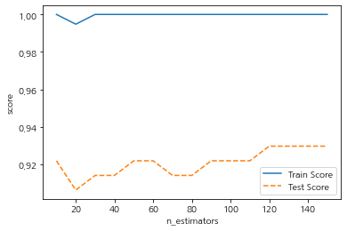

```python
# 모델 정확도 그래프 확인
plt.plot(para_n_tree, train_score, linestyle = "-", label = "Train Score")
plt.plot(para_n_tree, test_score, linestyle = "--", label = "Test Score")
plt.ylabel("score")
plt.xlabel("n_estimators")
plt.legend()
```

- 생성하는 결정 트리 수 증가에 따라 모델의 정확도는 train 데이터에서는 일정, test 데이터에서는 증가한다.
- Train/test 데이터의 성능 변화를 고려하여 50을 선택하는 것이 좋아보인다.

```python
# error 저장 리스트
oob_error = []

for v_n_estimator in range(1, 151):
    rf = RandomForestClassifier(n_estimators=v_n_estimator, oob_score=True, random_state=1234)
    rf.fit(df_train_x, df_train_y)
    oob_error.append(1 - rf.oob_score_)
```

[output not shown]

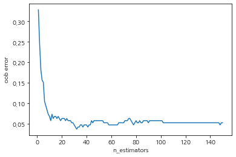

```python
# 그래프로 표현
plt.plot(range(1,151), oob_error)
plt.ylabel("oob error")
plt.xlabel("n_estimators")
```

- 생성하는 결정 트리 수 증가에 따라 모델의 정확도는 증가하며(OOB Error는 감소) 앞의 결과와 종합하여 50을 선택하는 것이 좋아보인다.

#### 최대 깊이

```python
# train, test 설명력 결과 저장
train_score = []
test_score = []

# max_depth: 최대 깊이 변경
para_depth = [depth for depth in range(1, 11)]

for v_max_depth in para_depth:
    rf = RandomForestClassifier(n_estimators=50, random_state=1234, max_depth=v_max_depth)
    rf.fit(df_train_x, df_train_y)
    train_score.append(rf.score(df_train_x, df_train_y))
    test_score.append(rf.score(df_test_x, df_test_y))

# 결과 저장
df_score_depth = pd.DataFrame()
df_score_depth["Depth"] = para_depth
df_score_depth["TrainScore"] = train_score
df_score_depth["TestScore"] = test_score
```

```python
# 모델 설명력 확인
df_score_depth.round(3)
```

|  | Depth | TrainScore | TestScore |
| --- | --- | --- | --- |
| 0 | 1 | 0.938 | 0.906 |
| 1 | 2 | 0.979 | 0.922 |
| 2 | 3 | 0.990 | 0.914 |
| 3 | 4 | 0.995 | 0.914 |
| 4 | 5 | 1.000 | 0.922 |
| 5 | 6 | 1.000 | 0.922 |
| 6 | 7 | 1.000 | 0.922 |
| 7 | 8 | 1.000 | 0.922 |
| 8 | 9 | 1.000 | 0.922 |
| 9 | 10 | 1.000 | 0.922 |

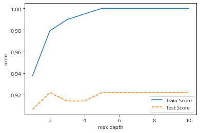

```python
# 모델 설명력 그래프 확인
plt.plot(para_depth, train_score, linestyle = "-", label = "Train Score")
plt.plot(para_depth, test_score, linestyle = "--", label = "Test Score")
plt.ylabel("score")
plt.xlabel("max depth")
plt.legend()
```

- 최대 깊이 증가에 따라 모델의 정확도는 증가한다.
- Train/Test 데이터를 고려하여 5를 선택할 것이다.

#### 분리 노드의 최소 자료 수

```python
# train, test 설명력 결과 저장
train_score = []
test_score = []

# min_samples_split: 분할하기 위한 노드의 최소 자료 수
para_split = [n_split * 2 for n_split in range(2, 21)]

for v_min_samples_split in para_split:
    rf = RandomForestClassifier(n_estimators=50, random_state=1234, max_depth=5, min_samples_split=v_min_samples_split)
    rf.fit(df_train_x, df_train_y)
    train_score.append(rf.score(df_train_x, df_train_y))
    test_score.append(rf.score(df_test_x, df_test_y))

# 결과 저장
df_score_split = pd.DataFrame()
df_score_split["MinSamplesSplit"] = para_split
df_score_split["TrainScore"] = train_score
df_score_split["TestScore"] = test_score
```

```python
# 모델 설명력 확인
df_score_split.round(3)
```

|  | MinSamplesSplit | TrainScore | TestScore |
| --- | --- | --- | --- |
| 0 | 4 | 1.000 | 0.922 |
| 1 | 6 | 1.000 | 0.922 |
| 2 | 8 | 0.990 | 0.914 |
| 3 | 10 | 0.990 | 0.914 |
| 4 | 12 | 0.990 | 0.914 |
| 5 | 14 | 0.990 | 0.922 |
| 6 | 16 | 0.990 | 0.922 |
| 7 | 18 | 0.990 | 0.914 |
| 8 | 20 | 0.990 | 0.914 |
| 9 | 22 | 0.990 | 0.914 |
| 10 | 24 | 0.990 | 0.914 |
| 11 | 26 | 0.990 | 0.914 |
| 12 | 28 | 0.990 | 0.914 |
| 13 | 30 | 0.990 | 0.914 |
| 14 | 32 | 0.990 | 0.914 |
| 15 | 34 | 0.990 | 0.914 |
| 16 | 36 | 0.990 | 0.914 |
| 17 | 38 | 0.984 | 0.914 |
| 18 | 40 | 0.984 | 0.922 |

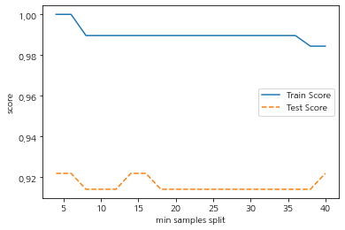

```python
# 모델 설명력 그래프 확인
plt.plot(para_split, train_score, linestyle = "-", label = "Train Score")
plt.plot(para_split, test_score, linestyle = "--", label = "Test Score")
plt.ylabel("score")
plt.xlabel("min samples split")
plt.legend()
```

- 분리 노드의 최소 자료 수 증가에 따라 모델의 정확도는 Train 데이터의 경우 감소, Test 데이터의 경우에는 감소와 증가를 반복한다.
- 이에 따라 14를 선택하는 것이 좋아보인다.

#### 잎사귀 노드의 최소 자료 수

```python
# train, test 설명력 결과 저장
train_score = []
test_score = []

# min_samples_leaf: 잎사귀 최소 자료 수
para_leaf = [n_leaf * 10 for n_leaf in range(1, 11)]

for v_min_samples_leaf in para_leaf:
    rf = RandomForestClassifier(n_estimators=50, random_state=1234, min_samples_split=14, min_samples_leaf=v_min_samples_leaf, max_depth=5)
    rf.fit(df_train_x, df_train_y)
    train_score.append(rf.score(df_train_x, df_train_y))
    test_score.append(rf.score(df_test_x, df_test_y))

# 결과 저장
df_score_leaf = pd.DataFrame()
df_score_leaf["MinSamplesLeaf"] = para_leaf
df_score_leaf["TrainScore"] = train_score
df_score_leaf["TestScore"] = test_score
```

```python
# 모델 설명력 확인
df_score_leaf.round(3)
```

|  | MinSamplesLeaf | TrainScore | TestScore |
| --- | --- | --- | --- |
| 0 | 10 | 0.964 | 0.906 |
| 1 | 20 | 0.948 | 0.914 |
| 2 | 30 | 0.943 | 0.906 |
| 3 | 40 | 0.938 | 0.906 |
| 4 | 50 | 0.953 | 0.906 |
| 5 | 60 | 0.943 | 0.891 |
| 6 | 70 | 0.599 | 0.758 |
| 7 | 80 | 0.599 | 0.758 |
| 8 | 90 | 0.599 | 0.758 |
| 9 | 100 | 0.599 | 0.758 |

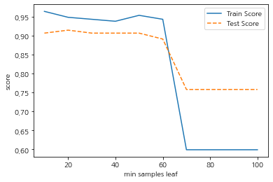

```python
# 모델 설명력 그래프 확인
plt.plot(para_leaf, train_score, linestyle = "-", label = "Train Score")
plt.plot(para_leaf, test_score, linestyle = "--", label = "Test Score")
plt.ylabel("score")
plt.xlabel("min samples leaf")
plt.legend()
```

- 잎사귀 노드 최소 자료 수 증가에 따라 모델의 정확도는 감소한다.
- Train/Test 데이터의 성능 변화를 고려하여 20을 선택할 것이다.

### 최종 모델

```python
rf = RandomForestClassifier(n_estimators=50, random_state=1234, min_samples_split=14, min_samples_leaf=20, max_depth=5)
rf_final.fit(df_train_x, df_train_y)
y_pred = rf_final.predict(df_test_x)

# Train, Test 데이터 설명력
print("Score on training set: {:.3f}".format(rf_final.score(df_train_x, df_train_y)))
print("Score on test set: {:.3f}".format(rf_final.score(df_test_x, df_test_y)))

# confusion matrix
print("Confusion matrix: \n{}".format(confusion_matrix(df_test_y, y_pred)))

# 목표변수의 빈도 불균형: f1 score로 모델 평가
print(classification_report(df_test_y, y_pred, digits=3))
```

[output not shown]

- 1 기준 f1-score는 82.0%이다.
- 1 기준 precision은 83.3%이다.
- 0 기준으로 보았을 때보다 예측 확률은 낮지만 80%가 넘는다는 점에서 충분히 사용 가능한 모델인 것 같다.

```python
# 변수명
v_feature_name = df_train_x.columns

# tree.feature_importance_로 설명변수 중요도 확인 및 테이블로 저장
df_importance = pd.DataFrame()
df_importance["Feature"] = v_feature_name
df_importance["Importance"] = rf_final.feature_importances_

# df_feature_importance의 테이블을 중요도 순으로 정렬
df_importance.sort_values("Importance", ascending=False, inplace=True)
df_importance.round(3)
```

|  | Feature | Importance |
| --- | --- | --- |
| 22 | worst_perimeter | 0.166 |
| 7 | mean_concave_points | 0.143 |
| 6 | mean_concavity | 0.120 |
| 27 | worst_concave_points | 0.119 |
| 20 | worst_radius | 0.098 |
| 23 | worst_area | 0.079 |
| 26 | worst_concavity | 0.059 |
| 2 | mean_perimeter | 0.053 |
| 0 | mean_radius | 0.042 |
| 3 | mean_area | 0.034 |
| 5 | mean_compactness | 0.022 |
| 13 | area_error | 0.021 |
| 17 | concave_points_error | 0.013 |
| 12 | perimeter_error | 0.009 |
| 28 | worst_symmetry | 0.004 |
| 4 | mean_smoothness | 0.003 |
| 1 | mean_texture | 0.002 |
| 10 | radius_error | 0.002 |
| 8 | mean_symmetry | 0.002 |
| 24 | worst_smoothness | 0.002 |
| 16 | concavity_error | 0.001 |
| 21 | worst_texture | 0.001 |
| 9 | mean_fractal_dimension | 0.001 |
| 15 | compactness_error | 0.001 |
| 11 | texture_error | 0.001 |
| 25 | worst_compactness | 0.001 |
| 19 | fractal_dimension_error | 0.001 |
| 18 | symmetry_error | 0.000 |
| 29 | worst_fractal_dimension | 0.000 |
| 14 | smoothness_error | 0.000 |

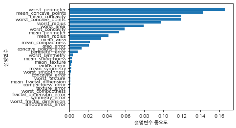

```python
# 설명변수 중요도 그래프
# 중요도가 높은 변수를 상위에 그림
df_importance.sort_values("Importance", ascending=True, inplace=True)
coordinates = range(len(df_importance))
plt.barh(y=coordinates, width=df_importance["Importance"])
plt.yticks(coordinates, df_importance["Feature"])
plt.xlabel("설명변수 중요도")
plt.ylabel("설명변수")
```

- 중요 설명변수는 worst_perimeter, mean_concave_points, mean_concavity, worst_concave_points 등이다.
- 의사결정나무와 비교했을 때, 변수들의 중요도 차이가 심하게 나지 않았다. 이는 의사결정나무가 모델 생성에 train 데이터를 많이 사용하기 때문에 생기는 차이인 것 같다.
- 0에 가까운 변수들이 중요하지 않은 것이 아니며, train 데이터에 따라서 변수들의 중요도는 변경될 수 있다.